# Day 14

## Review

**Random variable** (shorthand: r.v.):

- A rule for assigning a numerical value to each outcome of a random experiment
- General convention is to use a **captial letter toward the end of the alphabet** to notate these
  - i.e. $X,Y,Z$

> Flip a **fair** coin $3$ **independent** times

**Let** r.v. $X=\{\text{the number of tails observed}\}$

$$S=\{HHH,HHT,HTH,THH,HTT,THT,TTH,TTT\}$$

$$\begin{array}{|c|c|c|c|c|c|}
\hline
\textbf{Flip 1} & \textbf{Flip 2} & \textbf{Flip 3} \\
\hline
\text{H} & \text{H} & \text{H} \\
\hline
\text{H} & \text{H} & \text{T} \\
\hline
\text{H} & \text{T} & \text{H} \\
\hline
\text{T} & \text{H} & \text{H} \\
\hline
\text{H} & \text{T} & \text{T} \\
\hline
\text{T} & \text{H} & \text{T} \\
\hline
\text{T} & \text{T} & \text{H} \\
\hline
\text{T} & \text{T} & \text{T} \\
\hline
\end{array}$$

$$x=\text{the value after the experiement has been performed (not random)}$$

$$X=\text{the value before the experiement has been performed (still random)}$$

$$P(X=x)\quad \text{means the probability that r.v.} \ X \ \text{is equal to possible value} \ x$$

$$P(X>x) \quad \text{means the probability that r.v.} \ X \ \text{is greater than possible value} \ x$$

**Discrete Random Variables**

- The number of **possible values** in the **support** is **finite** or **countably** infinite

**Let** $Y=\{\text{The number of fish in a pond}\}$

- The **support** of $Y$, $S_Y=\{0,1,2,...\}$
- Can I have half a fish? Technically yes. But half a fish isn’t biologically important to count.
- If partial counts **feel arbitrary** then you’re more than likely working with a **discrete** variable
- I can hypothetically have **infinite** fish, but the **realized value** will always be a **whole** number

**Probability Distributions**

The form of a r.v.’s **probability distribution** depends on whether it is **continuous** or **discrete**

For a **discrete random variable** the probability distribution is often a *list* of all possible values the r.v. can take and their corresponding *probabilities of occurrence*

**Discrete probability distributions** satisfy the following two properties:

$$i. \quad 0 \le P(X=x) \le 1$$

$$ii. \quad \sum_x P(X=x)=1$$

We can draw a **histogram** so that the area of each bar above a given possible value of a r.v. is equal to it’s **probability of occurrence**

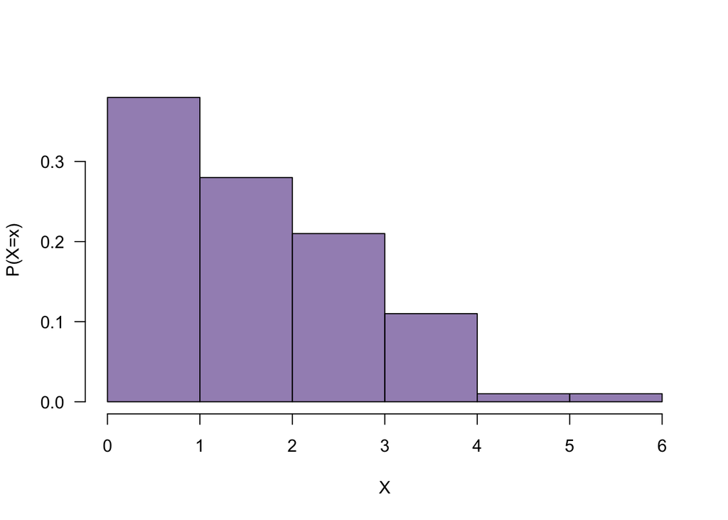

**Probability Distribution Mean**

For a **discrete probability distribution** of r.v. $X$, the mean is given by:

$$\mathbb{E}(X)=\mu=\sum_x xP(X=x)$$

We call this “the weighted sum of all probabilities of $x$”

$X=\{\text{number of customers in a line at the express checkout counter}\}$

$$\begin{array}{|c|c|c|c|c|c|c|}
\hline
x & 0 & 1 & 2 & 3 & 4 & 5 \\
\hline
P(X = x) & 0.4 & 0.2 & 0.15 & 0.1 & 0.1 & 0.05 \\
\hline
\end{array}$$

$$\mu_X=\sum_x xP(X=x)$$

$$=0(0.4)+1(0.2)+2(0.15)+3(0.1)+4(0.1)+5(0.05)=1.45$$

- This is the “average in the long run”

**Probability Distribution Variance**

Denoting the **variance** of discrete r.v. $X$:

$$\sigma^2_X \quad \text{or} \quad \text{Var}(X) \quad \text{or} \quad \mathbb{V}X$$

The general formula for the variance of r.v. $X$:

$$\sigma^2=\sum_x (x-\mu)^2 P(X=x)$$

$$=(0-1.45)^2(0.4)+(1-1.45)^2(0.2)+(2-1.45)^2(0.15)+(3-1.45)^2(0.1)+(4-1.45)^2(0.1)+(5-1.45)^2(0.05)$$

$$=2.4475$$

For **standard deviation**, defined loosely as the “average” distance from $\mu$ in the probability distribution:

$$\sigma=\sqrt{\sigma^2}$$

$$\sigma_X=\sqrt{2.4475}\approx 1.564$$

**Questions?**

**Goals for Today:**

1. Introduce the concept of continuous random variables
2. Discuss the distributions of continuous random variables

## Random Variables

### Continuous Random Variables

**Continuous r.v.:** The **support** consists of all numbers in an **interval** of the **real number line**

- This can be **any interval** or the entire line
- There are **too many numbers to count** (hence: uncountably infinite)

**Let** $W=\{\text{The proportion of couples receptive to couples therapy}\}$

- The possible values of $W$ are: $0 \le W \le 1$
- But $W$ can be **anything** in between $0$ and $1$
- Say, $w=0.012843199$ or maybe $w=0.99999991$

A way that we **discretized** continuous data prior involved putting it into *classes*

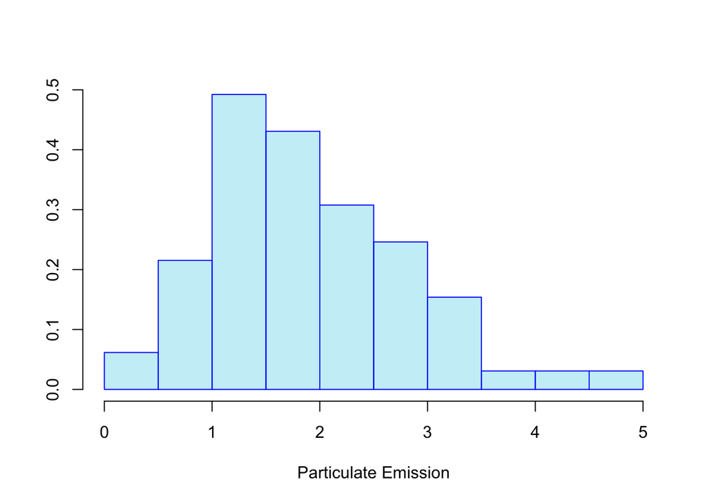

We can see how it’s possible to draw a curve across our histogram to represent the **general trend** of the data:

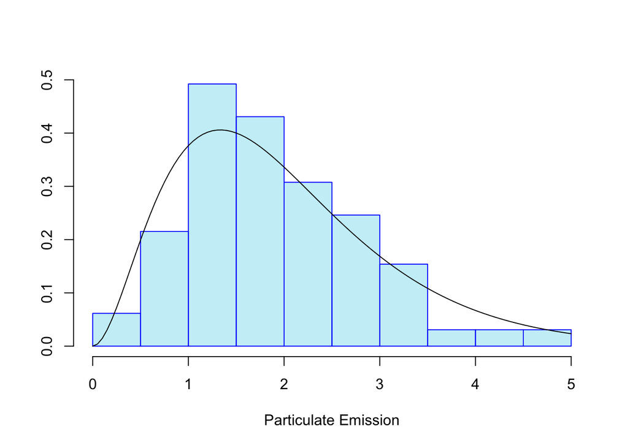

If we increase the data we collect, this histogram could get more detailed, the bars could narrow.

The more data we collect, the closer we would approach to the true **distribution** of the probabilities for our outcomes

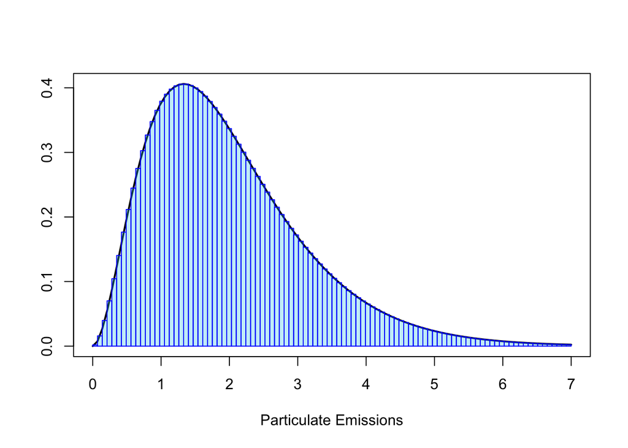

Inevitably we converge to a complete, smoothed curve:

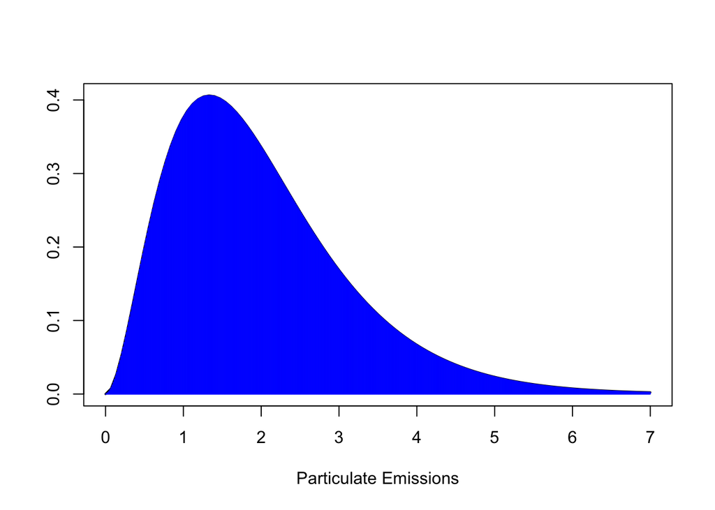

This curve is used to describe the distribution of a continuous random variable

- We refer to it as a **probability density curve**
- The density curve tells us what **proportion** of the population falls within any given interval
  - Using proper language: the **area under the curve** between any two values $a$ and $b$ represents the probability that *random variable* $X$ takes a value **between** $a$ and $b$

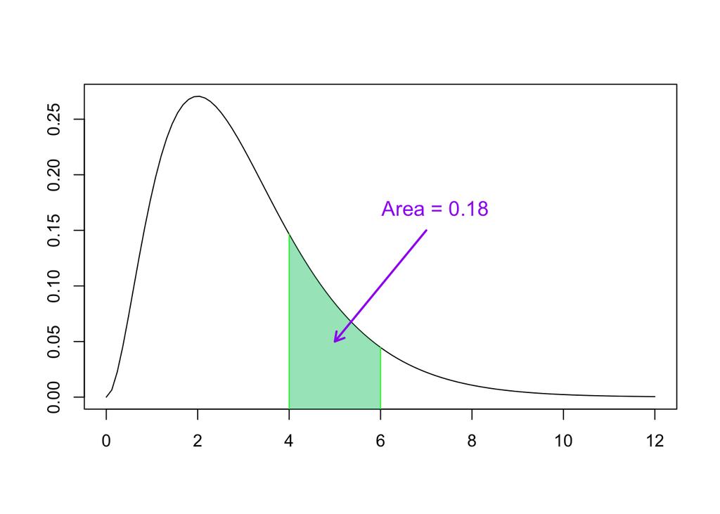

1. What is the proportion of the population between $4$ and $6$?
2. If a value is chosen at random from this population, what is the **probability** it will be between $4$ and $6$?

### Continuous Probability Distributions

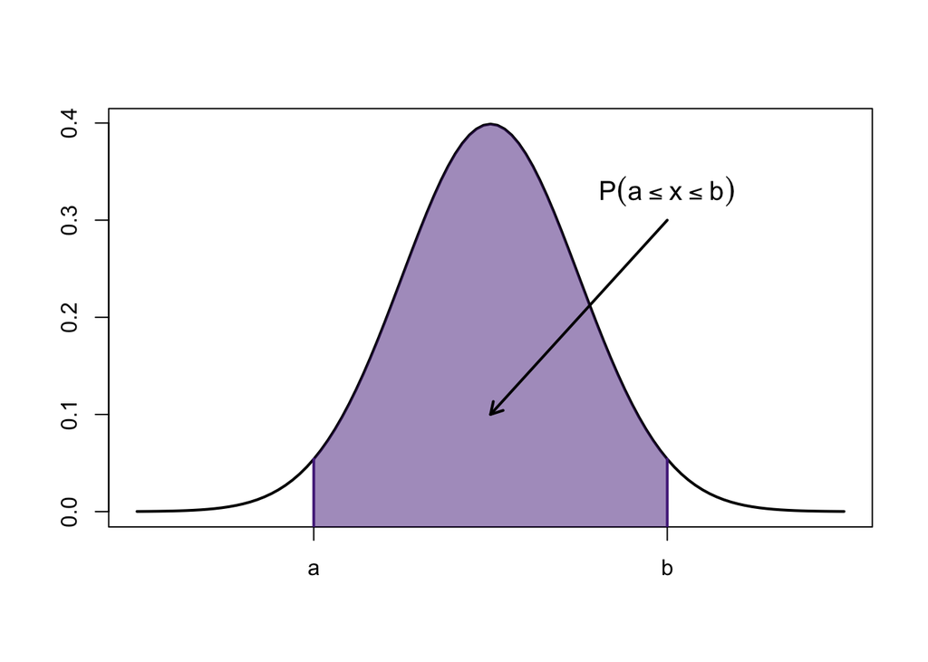

For a continuous r.v., probability is now “area under the curve”

- Only **intervals** will have *non-zero* probability
  - Any single value will have a probability of **zero**:

$$P(X=a)=0, \ \text{for any single number} \ a$$

$$P(X=b)=0, \ \text{for any single number} \ b$$

There’s also no difference between $\leq$ and $<$

$$P(X \leq 1)=P(X<1)$$

> Why is this?

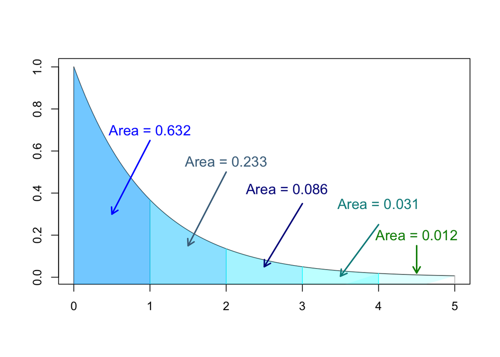

1. What is the total area of this curve?
2. What is the proportion of the population between $0$ and $1$?
3. What is the probability of any individual in this population being between $2$ and $3$?
4. What is the probability of any individual in this population being between $0$ and $2$?
5. What is the probability of any individual in this population being greater than $2$?

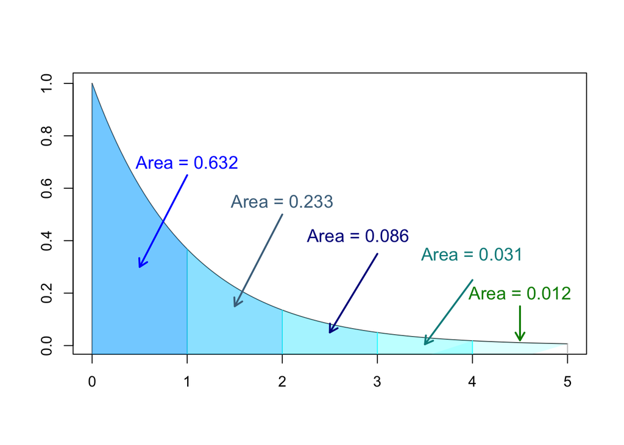

6. $P(2 \leq x < 4)$
7. $P(1 < x \leq 5)$

**Probability density curves** just refer to the graphical description of a **continuous** distribution

- This doesn’t inherently mean they’re going to be curves

If every possible value of $X$ is equally likely then it takes on a **uniform distribution**

- The curve for this distribution is a horizontal bar:

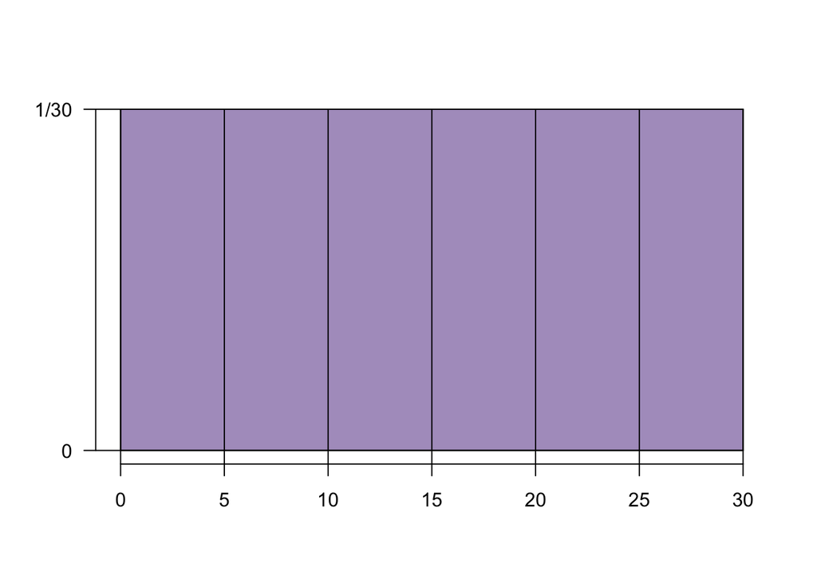

> The waiting time at a bus stop for the next bus to arrive is uniformally distributed between $0$ and $10$ minutes
1. Find the probability that the waiting time is less than $3$ minutes.
2. Find the probability that the waiting time is greater than $6$ minutes.
3. Find the probability that the waiting time is between $3$ and $8$ minutes.

The mean, variance, and standard deviation have the same interpretation for continuous variables as they do for discrete.

- To get these measurements we would need to understand calculus (or be a capable programmer)

Since neither of these are *viable options* for this course, we’ll instead study one of the most important examples of a continuous probability distribution: **the Normal Distribution**

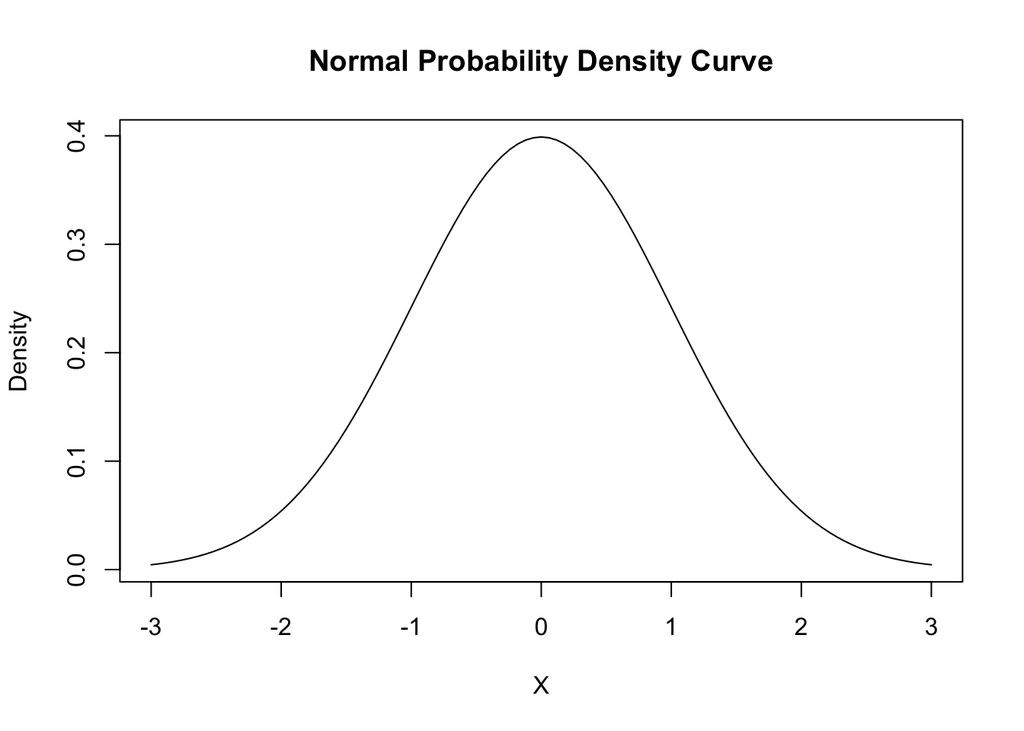